# Rectangle World Simulations

Manikya Alister

30/08/2022

## Set up rectangle world

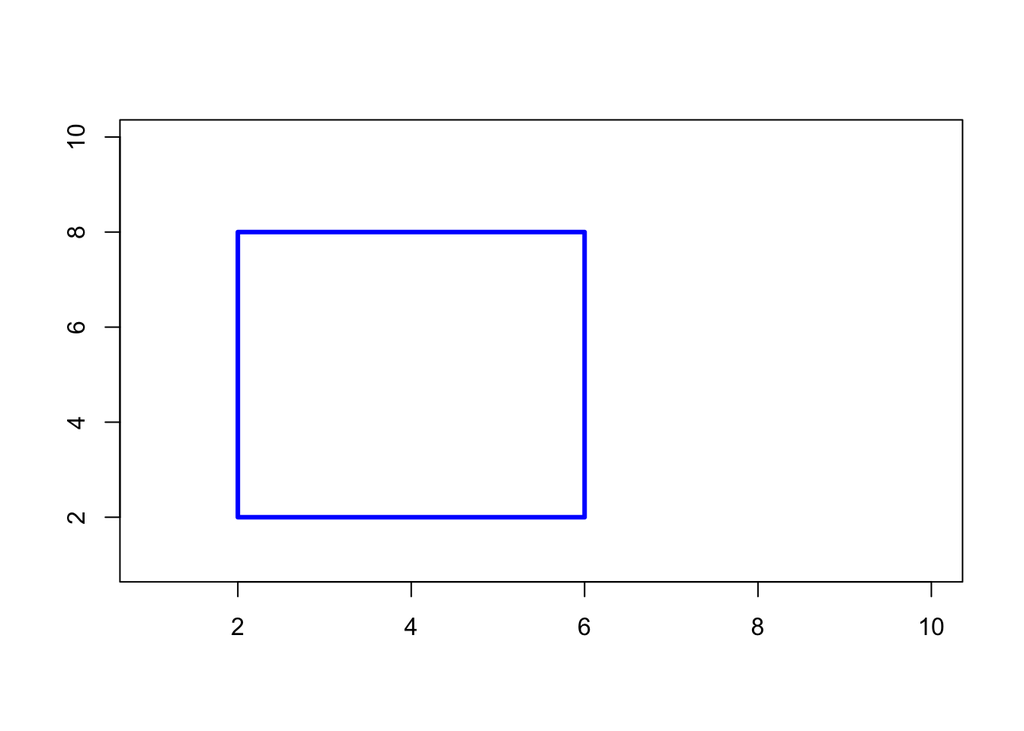

```r
# Define range of possible features
range = 1:10

# Create array with all possible rectangle coordinates within the range
borders = expand.grid(range,range,range,range)

for (i in 1:length(borders[,1])){ # replace duplicate rectangles with NA
  if (borders[i,1]-borders[i,3] > 0 | borders[i,2]-borders[i,4] > 0){
    borders[i,] = NA
  }
}

borders = borders[complete.cases(borders),] # delete rows that previously held duplicate rectangles (there was probably a better way to do this)

# Define the true category region
cat1 = c(2,2,6,8)

#visualize true category region
plot(c(1,max(range)), c(1, max(range)), type= "n", xlab = "", ylab = "")
rect(cat1[1],cat1[2],cat1[3],cat1[4],border = "blue", lwd = 3)
```

## Sample some observations

For this simulation I’m going to do a maximum of 10 observations, 5 positive examples and 5 negative examples. I’m interested to see how the different learning strategies (weak, strong, pedagogical) generalise given different quantities of examples (e.g., 1, 3, 5 of each positive/negative evidence type).

This sampling is, I guess, a form of weak sampling, but it’s not truly weak because I’m ensuring an equal number of positive and negative examples.

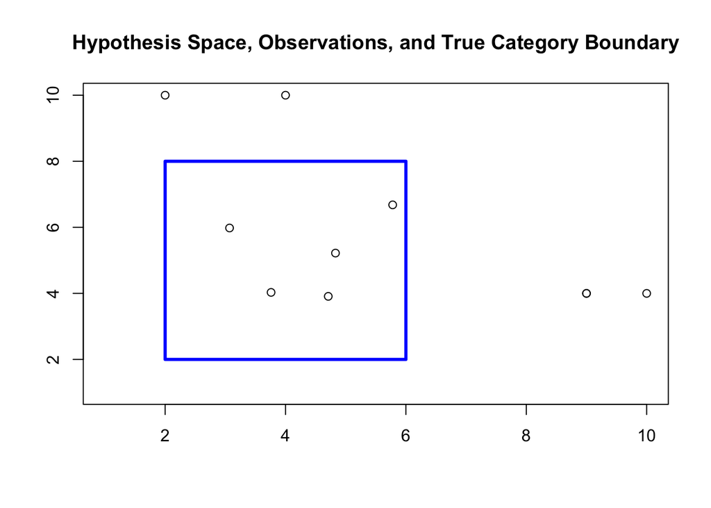

```r
nObs = 10
# Positive examples
pX = round(runif(nObs/2, cat1[1],cat1[3]),2) # X coordinates
pY = round(runif(nObs/2, cat1[2],cat1[4]),2) # Y coordinates
pos = cbind(pX,pY,"1")

## Need to find a  better way to sample negative evidence
neg = weakSampler(20)
neg = neg[neg[,"category"]== "none",]
neg = neg[1:5,]

# set up different arrays with different numbers of observations
obs1 = rbind(pos[1,],neg[1,])
colnames(obs1) = c("x","y","category")

obs3 = rbind(pos[1:3,],neg[1:3,])
colnames(obs3) = c("x","y","category")

obs5 = rbind(pos[1:5,],neg[1:5,])
colnames(obs5) = c("x","y","category")

# visualize observations
plot(c(1,max(range)), c(1, max(range)), type= "n", xlab = "", ylab = "", main = "Hypothesis Space, Observations, and True Category Boundary")
rect(cat1[1],cat1[2],cat1[3],cat1[4],border = "blue", lwd = 3)
points(obs5)
```

```r
ls1 = lsLearner(borders, obs1)
ls3 = lsLearner(borders, obs3)
ls5 = lsLearner(borders, obs5)
```

*transparency of block corresponds to probability*

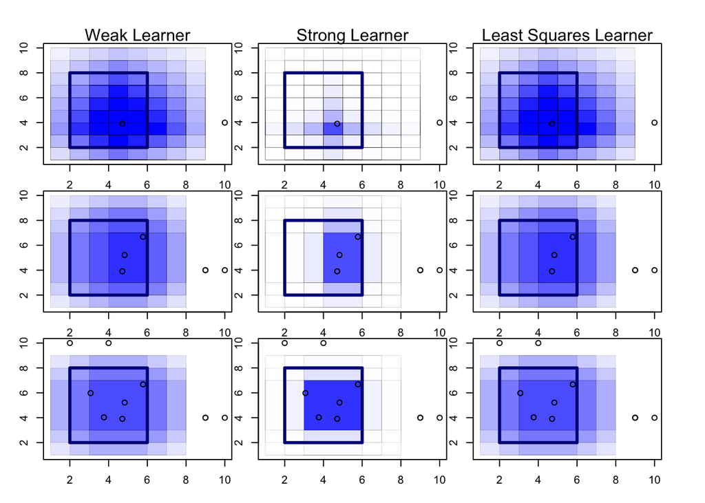

The above plots aren’t great at showing which triangle is most likely because when the rectangles overlap it inflates how probable a rectangle appears.

What about just showing the highest probability rectangle? Main problem with this is it doesn’t really show the uncertainty or distribution of possible rectangles, but it will do a better job of showing differences between models.

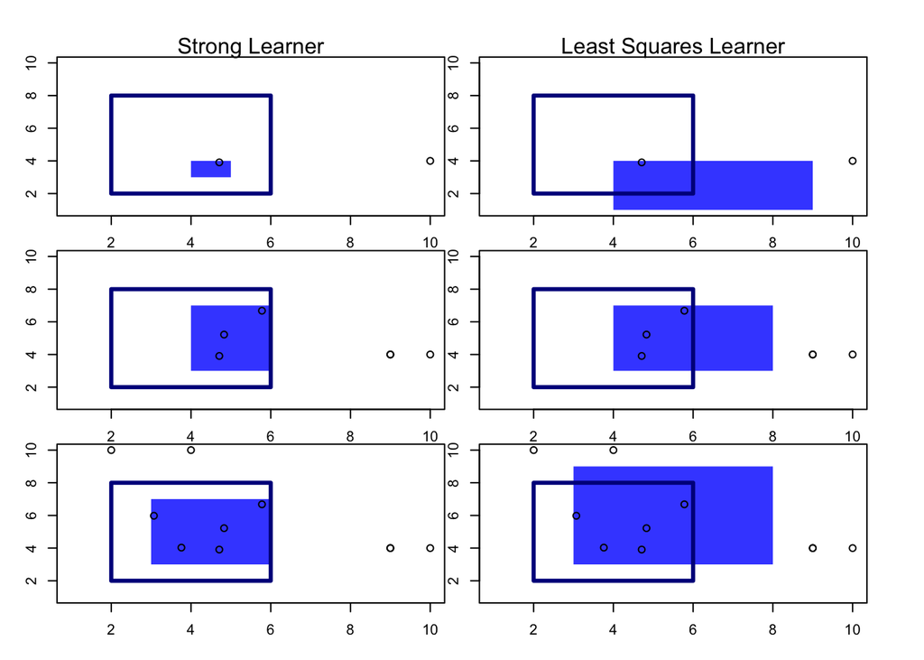

```r
par(omi=rep(0.3, 4), mar=c(1,1,1,1), mfrow=c(3,2))

plotStrong1(strong1, obs1, cat1)
mtext("Strong Learner", side = 3)

plotLS1(ls1, obs1, cat1)
mtext("Least Squares Learner", side = 3)

plotStrong1(strong3, obs3, cat1)

plotLS1(ls3, obs3, cat1)

plotStrong1(strong5, obs5, cat1)

plotLS1(ls5, obs5, cat1)
```

Ordinal hypotheses?

What happens if I just raise the strong sampling learner’s likelihood to the power of alpha? An alpha of 0 should basically be weak sampling and alpha = 1 would be strong sampling. Alpha = 2 should be a hacky way of making a pedagogical model.

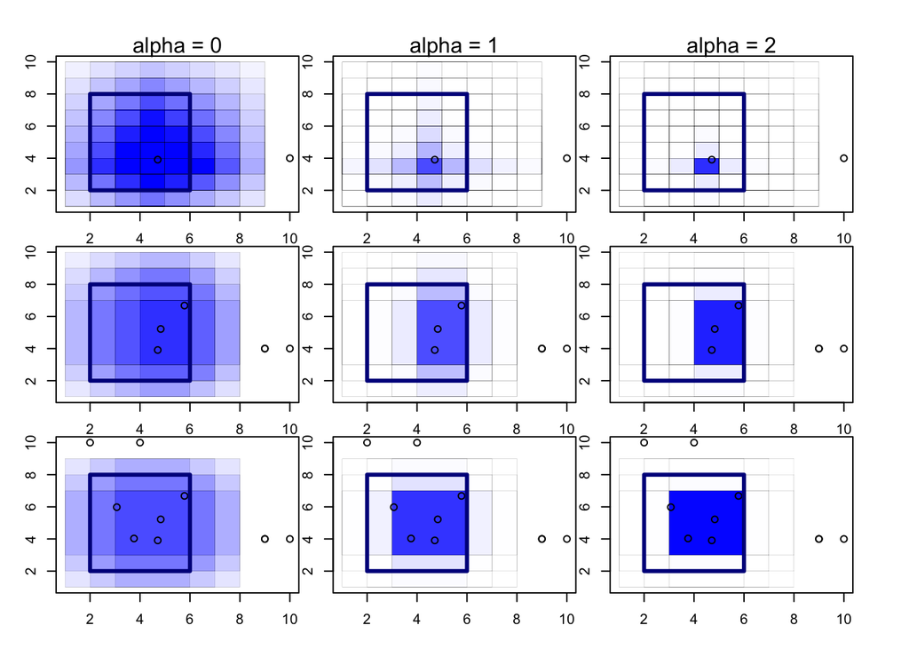

## To Do:

- Code proper pedagogical model where the learner tries to figure out what rectangle would be the *most* probable given the points that have been shown.
- Code priors into these models. What would happen if the learner has a prior favoring larger hypotheses?